# Chapter 6 Lab 2 - Fuzzy C-Means

# Goal

In this lab, we will learn how to use Fuzzy C-Means for cluster analysis, applied on the DoTalicious data set.

We are using `fanny` function from the `cluster` package. More about the cluster package can be seen at: https://cran.r-project.org/web/packages/cluster/cluster.pdf, see page 38.

## Brief refresher

Fuzzy C-Means extends K-Means by allowing data points to have membership with more than one clusters. For example, a data point can have 40% membership with Cluster 1 and 60% membership with Cluster 2.

## Preparation

The following steps in prepraration of the data is similar to Lab 6.1.

```r
library(cluster) # for Fuzzy C-means algo
library(ggplot2)
library("GGally") # for visualization of scatterplot matrix
library(factoextra) # for visualization of results
```

# Step 1: Load the data set

Again, this step is similar to Lab 6.1.

```r
# read the CSV file
Dota_Data <- read.csv("DoTalicious_cleaned1000players.csv", fileEncoding="UTF-8-BOM")
summary(Dota_Data)
```

```
##     PlayerID       GamesPlayed         GamesWon         GamesLeft
##  Min.   :   0.0   Min.   :   0.00   Min.   :   0.00   Min.   : 0.000
##  1st Qu.: 242.8   1st Qu.:   3.00   1st Qu.:   1.00   1st Qu.: 0.000
##  Median : 499.5   Median :  15.00   Median :   7.00   Median : 0.000
##  Mean   : 497.7   Mean   :  92.24   Mean   :  50.31   Mean   : 1.649
##  3rd Qu.: 750.2   3rd Qu.:  90.00   3rd Qu.:  47.25   3rd Qu.: 2.000
##  Max.   :1000.0   Max.   :3156.00   Max.   :1764.00   Max.   :40.000
##     Ditches            Points        SkillLevel            Kills
##  Min.   : 0.0000   Min.   : 626.8   Length:868         Min.   :    0.0
##  1st Qu.: 0.0000   1st Qu.: 962.1   Class :character   1st Qu.:   11.0
##  Median : 0.0000   Median : 996.7   Mode  :character   Median :   74.0
##  Mean   : 0.7108   Mean   :1014.8                      Mean   :  608.0
##  3rd Qu.: 1.0000   3rd Qu.:1046.7                      3rd Qu.:  512.8
##  Max.   :18.0000   Max.   :2010.2                      Max.   :23742.0
##   KillsPerMin         Deaths           Assists         CreepsKilled
##  Min.   :0.0000   Min.   :    0.0   Min.   :    0.0   Min.   :     0.0
##  1st Qu.:0.0900   1st Qu.:   17.0   1st Qu.:   18.0   1st Qu.:   159.5
##  Median :0.1300   Median :   92.5   Median :  124.0   Median :   979.0
##  Mean   :0.1316   Mean   :  544.5   Mean   :  950.7   Mean   :  7628.0
##  3rd Qu.:0.1700   3rd Qu.:  554.0   3rd Qu.:  863.5   3rd Qu.:  6723.0
##  Max.   :0.4200   Max.   :16988.0   Max.   :34390.0   Max.   :372360.0
##   CreepsDenied     NeutralsKilled    TowersDestroyed   RaxsDestroyed
##  Min.   :    0.0   Min.   :    0.0   Min.   :   0.00   Min.   :   0.00
##  1st Qu.:   12.0   1st Qu.:   16.0   1st Qu.:   1.00   1st Qu.:   0.00
##  Median :   76.0   Median :  145.5   Median :   7.00   Median :   3.00
##  Mean   :  676.9   Mean   : 1258.3   Mean   :  70.71   Mean   :  29.71
##  3rd Qu.:  540.8   3rd Qu.: 1126.8   3rd Qu.:  61.50   3rd Qu.:  26.00
##  Max.   :43910.0   Max.   :42900.0   Max.   :2601.00   Max.   :1141.00
##   TotalTime
##  Length:868
##  Class :character
##  Mode  :character
##
##
##
```

Clean up and set the correct data type. This is similar to Lab 6.1, so you can skip over this step if you already have the data cleaned and transformed.

```r
# convert TotalTime
Dota_Data$TotalTime <- as.numeric(Dota_Data$TotalTime)
# exclude the row with SillLevel = SkillLevelNull
Dota_Data$SkillLevel <- as.factor(Dota_Data$SkillLevel)
Dota_Data <- Dota_Data[!(Dota_Data$SkillLevel == " SkillLevelNull"),]

# use factor in place of as.factor to remove " SkillLevelNull" from the list of factors
Dota_Data$SkillLevel <- factor(Dota_Data$SkillLevel)

# make the names of levels descriptive
levels(Dota_Data$SkillLevel) <- c("N", "B", "I", "A")

# set row.names for visualization of clusters later
row.names(Dota_Data) <- make.names(Dota_Data[,"SkillLevel"], unique = TRUE)

# exclude PlayerID
Dota_Data <- Dota_Data[-1]

summary(Dota_Data)
```

```
##   GamesPlayed         GamesWon         GamesLeft         Ditches
##  Min.   :   0.00   Min.   :   0.00   Min.   : 0.000   Min.   : 0.0000
##  1st Qu.:   3.00   1st Qu.:   1.00   1st Qu.: 0.000   1st Qu.: 0.0000
##  Median :  15.00   Median :   7.00   Median : 0.000   Median : 0.0000
##  Mean   :  92.24   Mean   :  50.33   Mean   : 1.647   Mean   : 0.7116
##  3rd Qu.:  89.50   3rd Qu.:  47.50   3rd Qu.: 2.000   3rd Qu.: 1.0000
##  Max.   :3156.00   Max.   :1764.00   Max.   :40.000   Max.   :18.0000
##
##      Points       SkillLevel     Kills          KillsPerMin
##  Min.   : 626.8   N:447      Min.   :    0.0   Min.   :0.0000
##  1st Qu.: 962.3   B:391      1st Qu.:   11.0   1st Qu.:0.0900
##  Median : 996.8   I: 17      Median :   74.0   Median :0.1300
##  Mean   :1014.9   A: 12      Mean   :  608.1   Mean   :0.1317
##  3rd Qu.:1047.0              3rd Qu.:  514.5   3rd Qu.:0.1700
##  Max.   :2010.2              Max.   :23742.0   Max.   :0.4200
##
##      Deaths           Assists         CreepsKilled     CreepsDenied
##  Min.   :    0.0   Min.   :    0.0   Min.   :     0   Min.   :    0.0
##  1st Qu.:   17.0   1st Qu.:   18.0   1st Qu.:   159   1st Qu.:   12.0
##  Median :   92.0   Median :  123.0   Median :   975   Median :   76.0
##  Mean   :  544.5   Mean   :  950.9   Mean   :  7628   Mean   :  677.2
##  3rd Qu.:  554.0   3rd Qu.:  865.0   3rd Qu.:  6668   3rd Qu.:  541.5
##  Max.   :16988.0   Max.   :34390.0   Max.   :372360   Max.   :43910.0
##
##  NeutralsKilled  TowersDestroyed   RaxsDestroyed       TotalTime
##  Min.   :    0   Min.   :   0.00   Min.   :   0.00   Min.   :   1349
##  1st Qu.:   16   1st Qu.:   1.00   1st Qu.:   0.00   1st Qu.:   6255
##  Median :  145   Median :   7.00   Median :   3.00   Median :  35070
##  Mean   : 1257   Mean   :  70.71   Mean   :  29.71   Mean   : 228343
##  3rd Qu.: 1114   3rd Qu.:  61.00   3rd Qu.:  26.00   3rd Qu.: 220815
##  Max.   :42900   Max.   :2601.00   Max.   :1141.00   Max.   :4294920
##                                                      NA's   :1
```

Check if there is any missing value (NA here means Not Available). If it returns *False*, we’re good to go. If not, we will need to omit the rows that has NAs in them.

```r
anyNA(Dota_Data)
```

```
## [1] TRUE
```

```r
Dota_Data = na.omit(Dota_Data)
```

Unlike with Lab 6.1, there is no need to scale the data, because `fanny` has a built-in feature to scale the data.

Finally, similar to `K-means` Fuzzy C-Means also only works with numeric variables, so we will exclude `SkillLevel` from the data.

```r
attribs_except_skill <- -which(names(Dota_Data) %in% c("SkillLevel"))
DotaData_NoSkill <- Dota_Data[, attribs_except_skill]
```

# Step 2: Run Fuzzy C-means

From Lab 6.1, we know that with `K-Means`, `K=5` is a good number of clusters, so we are going to use the same setting here.

```r
#setting the seed
set.seed(2063)
#setting the K value
selected_K <- 5

#call the fanny function to determine the fuzzy clusters

fit <- fanny(DotaData_NoSkill,
             k = selected_K,
             metric = 'euclidean',
             stand = TRUE,
             memb.exp = 1.5)

# show membership
head(fit$membership)
```

```
##            [,1]       [,2]       [,3]       [,4]         [,5]
## B   0.407007945 0.10822867 0.06405158 0.07064448 0.3500673246
## B.1 0.028375200 0.42548998 0.19278303 0.35102851 0.0023232801
## N   0.005927317 0.07811688 0.54168430 0.37357046 0.0007010481
## B.2 0.396848416 0.32314026 0.09948253 0.15467989 0.0258489087
## N.1 0.051677775 0.34062106 0.13528155 0.46577938 0.0066402410
## N.2 0.007406677 0.12255195 0.25261466 0.61661890 0.0008078186
```

The output shows the membership assigned to the data.

Then similar to the previous lab, we will look at the data and clusters. Here since every data point would belong to several clusters, you can either inspect the belonginess per data point through the membership variable above to look at the data with a cluster variable that is computed as the max memebership given all cluster values. So given the rows above for example, the first data point would belong to Cluster 1, and the second to Cluster 2, etc.

```r
#cluster sizes
fit$size
```

[output not shown]

```r
#a look at the data and clusters
DotaData_NoSkill$cluster <- fit$cluster
#showing first 30 rows
head(DotaData_NoSkill, 30)
```

|  | GamesPlayed | GamesWon | GamesLeft | Ditches | Points | Kills | KillsPerMin | Deaths | Assists | CreepsKilled | CreepsDenied | NeutralsKilled | TowersDestroyed | RaxsDestroyed | TotalTime | cluster |
| --- | --- | --- | --- | --- | --- | --- | --- | --- | --- | --- | --- | --- | --- | --- | --- | --- |
| B | 447 | 248 | 6 | 6 | 1111.360 | 2271 | 0.12 | 1889 | 4201 | 38736 | 3058 | 3456 | 355 | 151 | 1116780 | 1 |
| B.1 | 66 | 39 | 0 | 0 | 989.882 | 373 | 0.13 | 450 | 745 | 4484 | 518 | 455 | 49 | 23 | 169800 | 2 |
| N | 3 | 0 | 0 | 0 | 1000.000 | 11 | 0.11 | 28 | 18 | 186 | 10 | 7 | 0 | 0 | 6180 | 3 |
| B.2 | 100 | 59 | 5 | 1 | 1228.460 | 1079 | 0.26 | 448 | 934 | 13943 | 1885 | 1417 | 132 | 36 | 250200 | 1 |
| N.1 | 1 | 1 | 0 | 0 | 1020.000 | 9 | 0.28 | 2 | 10 | 38 | 8 | 3 | 0 | 0 | 1944 | 4 |
| N.2 | 21 | 8 | 0 | 0 | 960.711 | 133 | 0.13 | 144 | 200 | 2064 | 172 | 332 | 7 | 6 | 60000 | 4 |
| B.3 | 17 | 7 | 0 | 0 | 918.816 | 71 | 0.10 | 140 | 125 | 849 | 40 | 41 | 2 | 5 | 41940 | 3 |
| B.4 | 22 | 11 | 0 | 1 | 995.875 | 130 | 0.15 | 130 | 210 | 1725 | 199 | 457 | 18 | 7 | 53580 | 4 |
| N.3 | 3 | 2 | 0 | 0 | 1000.000 | 18 | 0.15 | 17 | 30 | 162 | 31 | 78 | 5 | 2 | 7140 | 4 |
| N.4 | 211 | 84 | 5 | 1 | 925.548 | 1034 | 0.11 | 1559 | 1827 | 13498 | 859 | 2360 | 106 | 33 | 542100 | 1 |

[output cut: 20 more lines]

# Step 5: Visualize the result

As the final step, the result should be visualized for the expert to scrutinize and decide if the results make sense. For this purpose, similar to Lab 5.1, we will use the package `factoextra`, which provides the function `fviz_cluster` capable of visualizing the results of many clustering algorithms. Check out the documentation [here] (https://cran.r-project.org/web/packages/factoextra/factoextra.pdf)

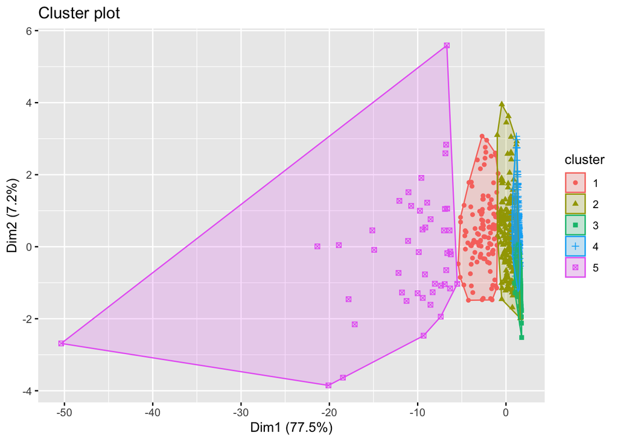

```r
factoextra::fviz_cluster(fit, data = DotaData_NoSkill, geom = "point")
```

Notice how the vizualization is quite similar to that of `K-means` from Lab 6.1.

Re-visualize the clusters with our `SkillLevel` variable as labels.

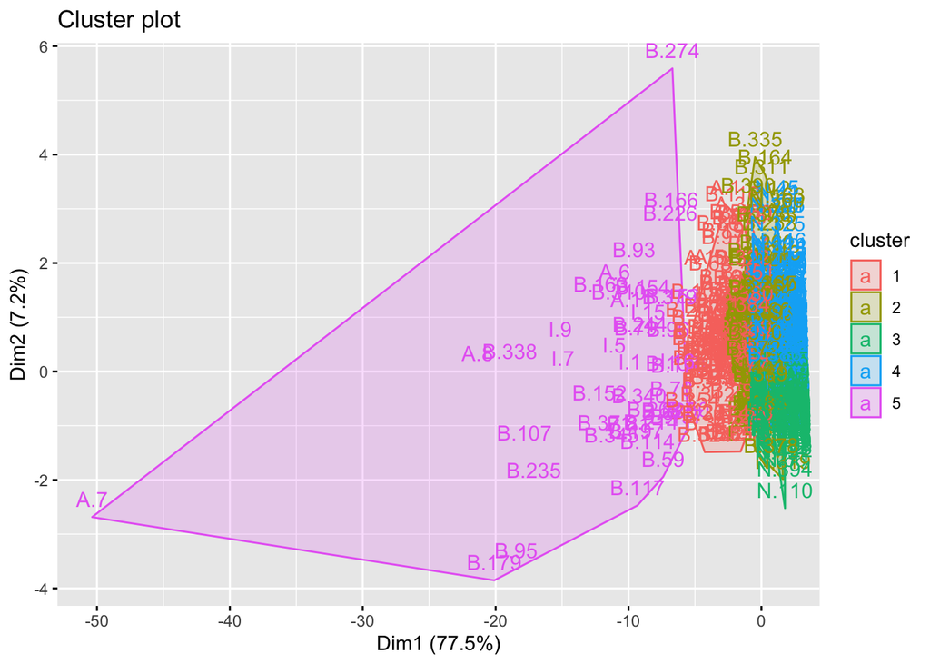

```r
factoextra::fviz_cluster(fit, data = DotaData_NoSkill, geom = "text")
```

You may want to tweak the plot to make it easier for expert interpretation, e.g., using other kinds of labels.

Finally, visualize the silhouette plot to show the quality of the clustering.

```
##   cluster size ave.sil.width
## 1       1  112          0.13
## 2       2  157         -0.05
## 3       3  299          0.44
## 4       4  252          0.26
## 5       5   46          0.02
```

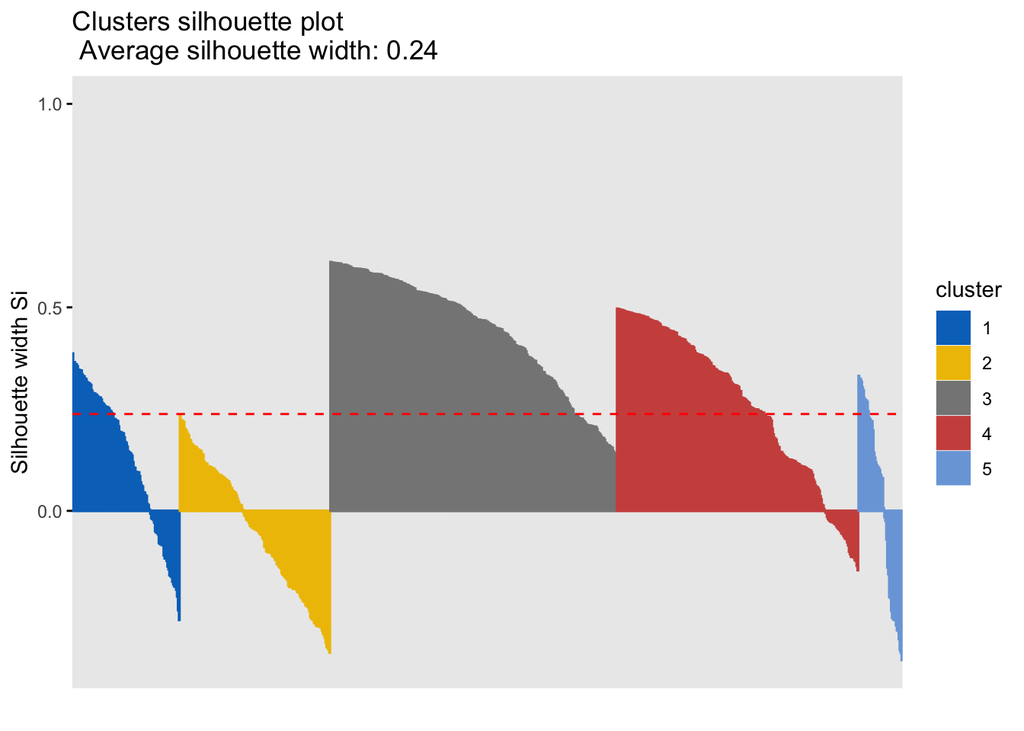

```r
# visualize silhouette coefficients
factoextra::fviz_silhouette(fit, palette = "jco", ggtheme = theme_minimal())
```

The plot shows all data points’ silhouette values, each of which ranges between -1 and 1, sorted in decreasing order in each cluster. A high Silhouette value, i.e., close to 1, indicates the data point well matches its assigned cluster. Ideally, we would like to see all values close to 1, which is clearly not the case here.

Overall, our clustering result is not very good, with the average silhouette value (or width) being only 0.24. Some potential reasons for this include:

- the data does not have good cluster tendency, i.e., they might be sparse and separated, or
- the data has cluster tendency, but the clusters may not be spherical in shape.

# Further Readings

- [factoextra v1.0.5](https://www.rdocumentation.org/packages/factoextra/versions/1.0.5), by Alboukadel Kassambara, 2018

# Conclusion

In this lab, we showed you how to use Fuzzy C-means for cluster analysis. This lab follows the previous lab as `Fuzzy C-means` is similar to `K-means`. The clusters also look similar. But you can play around with the data or the parameters and see how the clusters vary.